# DATA621-FinalProject-SmoothOperators

Rob Hodde, Matt Farris, Jeffrey Burmood, Bin Lin

5/11/2017

## Problem Description

Our final project will explore, analyze and model a data set containing information on approximately 5,000 movies. The dataset contains movie data extracted from the IMDB website and is available on Kaggle.com.

The project will develop predictive models for two questions:

1. Will the movie make money, lose money, or break even (approximately)?
2. What is the anticipated gross margin (profit) for the movie?

## Data Exploration

| VAR | TYPE |
| --- | --- |
| duration | integer |
| director_facebook_likes | integer |
| actor_3_facebook_likes | integer |
| actor_1_facebook_likes | integer |
| gross | integer |
| movie_title | character |
| num_voted_users | integer |
| cast_total_facebook_likes | integer |
| facenumber_in_poster | integer |
| content_rating | character |
| budget | double |
| title_year | integer |
| actor_2_facebook_likes | integer |
| imdb_score | double |

```
##     duration   director_facebook_likes actor_3_facebook_likes
##  Min.   : 37   Min.   :    0.0         Min.   :    0.0
##  1st Qu.: 95   1st Qu.:   10.0         1st Qu.:  188.8
##  Median :106   Median :   60.0         Median :  433.0
##  Mean   :110   Mean   :  792.9         Mean   :  761.8
##  3rd Qu.:120   3rd Qu.:  232.5         3rd Qu.:  690.0
##  Max.   :330   Max.   :23000.0         Max.   :23000.0
##
##  actor_1_facebook_likes     gross           movie_title
##  Min.   :     0.0       Min.   :      162   Length:3828
##  1st Qu.:   737.5       1st Qu.:  7452337   Class :character
##  Median :  1000.0       Median : 28854152   Mode  :character
##  Mean   :  7664.1       Mean   : 51694432
##  3rd Qu.: 12250.0       3rd Qu.: 66004138
##  Max.   :640000.0       Max.   :760505847
##
##  num_voted_users   cast_total_facebook_likes facenumber_in_poster
##  Min.   :     22   Min.   :     0            Min.   : 0.000
##  1st Qu.:  18267   1st Qu.:  1880            1st Qu.: 0.000
##  Median :  52380   Median :  3962            Median : 1.000
##  Mean   : 103908   Mean   : 11396            Mean   : 1.379
##  3rd Qu.: 125643   3rd Qu.: 16128            3rd Qu.: 2.000
##  Max.   :1689764   Max.   :656730            Max.   :43.000
##
##    content_rating     budget            title_year
##  R        :1736   Min.   :2.180e+02   Min.   :1927
##  PG-13    :1326   1st Qu.:1.000e+07   1st Qu.:1999
##  PG       : 574   Median :2.500e+07   Median :2005
##  G        :  89   Mean   :4.548e+07   Mean   :2003
##  Not Rated:  40   3rd Qu.:5.000e+07   3rd Qu.:2010
##  Unrated  :  24   Max.   :1.222e+10   Max.   :2016
##  (Other)  :  39
##  actor_2_facebook_likes   imdb_score
##  Min.   :     0.0       Min.   :1.600
##  1st Qu.:   373.8       1st Qu.:5.900
##  Median :   677.0       Median :6.600
##  Mean   :  1994.6       Mean   :6.459
##  3rd Qu.:   975.0       3rd Qu.:7.200
##  Max.   :137000.0       Max.   :9.300
##
```

|  | duration | director_facebook_likes | actor_3_facebook_likes | actor_1_facebook_likes |
| --- | --- | --- | --- | --- |
| duration | 1.0000000 | 0.1822411 | 0.1279962 | 0.0863409 |
| director_facebook_likes | 0.1822411 | 1.0000000 | 0.1184843 | 0.0905543 |
| actor_3_facebook_likes | 0.1279962 | 0.1184843 | 1.0000000 | 0.2526590 |
| actor_1_facebook_likes | 0.0863409 | 0.0905543 | 0.2526590 | 1.0000000 |
| num_voted_users | 0.3434487 | 0.3013255 | 0.2697667 | 0.1817812 |
| cast_total_facebook_likes | 0.1232351 | 0.1197195 | 0.4895509 | 0.9450371 |
| facenumber_in_poster | 0.0263907 | -0.0478417 | 0.1055483 | 0.0614101 |
| budget | 0.0696018 | 0.0189881 | 0.0408678 | 0.0173849 |
| title_year | -0.1311001 | -0.0464926 | 0.1144145 | 0.0929673 |
| actor_2_facebook_likes | 0.1311685 | 0.1172937 | 0.5540722 | 0.3910139 |
| imdb_score | 0.3655775 | 0.1915761 | 0.0661996 | 0.0939598 |

|  | num_voted_users | cast_total_facebook_likes | facenumber_in_poster | budget |
| --- | --- | --- | --- | --- |
| duration | 0.3434487 | 0.1232351 | 0.0263907 | 0.0696018 |
| director_facebook_likes | 0.3013255 | 0.1197195 | -0.0478417 | 0.0189881 |
| actor_3_facebook_likes | 0.2697667 | 0.4895509 | 0.1055483 | 0.0408678 |
| actor_1_facebook_likes | 0.1817812 | 0.9450371 | 0.0614101 | 0.0173849 |
| num_voted_users | 1.0000000 | 0.2516946 | -0.0324633 | 0.0678793 |
| cast_total_facebook_likes | 0.2516946 | 1.0000000 | 0.0837393 | 0.0298442 |
| facenumber_in_poster | -0.0324633 | 0.0837393 | 1.0000000 | -0.0215767 |
| budget | 0.0678793 | 0.0298442 | -0.0215767 | 1.0000000 |
| title_year | 0.0172947 | 0.1230087 | 0.0716142 | 0.0452068 |
| actor_2_facebook_likes | 0.2473172 | 0.6424574 | 0.0720087 | 0.0367048 |
| imdb_score | 0.4792715 | 0.1073363 | -0.0671658 | 0.0298854 |

|  | title_year | actor_2_facebook_likes |
| --- | --- | --- |
| duration | -0.1311001 | 0.1311685 |
| director_facebook_likes | -0.0464926 | 0.1172937 |
| actor_3_facebook_likes | 0.1144145 | 0.5540722 |
| actor_1_facebook_likes | 0.0929673 | 0.3910139 |
| num_voted_users | 0.0172947 | 0.2473172 |
| cast_total_facebook_likes | 0.1230087 | 0.6424574 |
| facenumber_in_poster | 0.0716142 | 0.0720087 |
| budget | 0.0452068 | 0.0367048 |
| title_year | 1.0000000 | 0.1186388 |
| actor_2_facebook_likes | 0.1186388 | 1.0000000 |
| imdb_score | -0.1357930 | 0.1031776 |

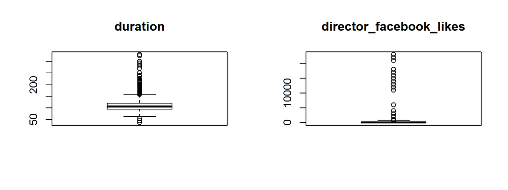

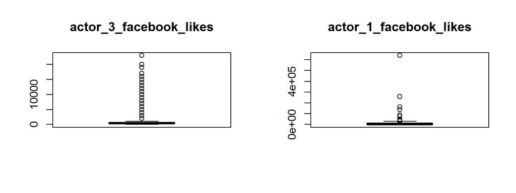

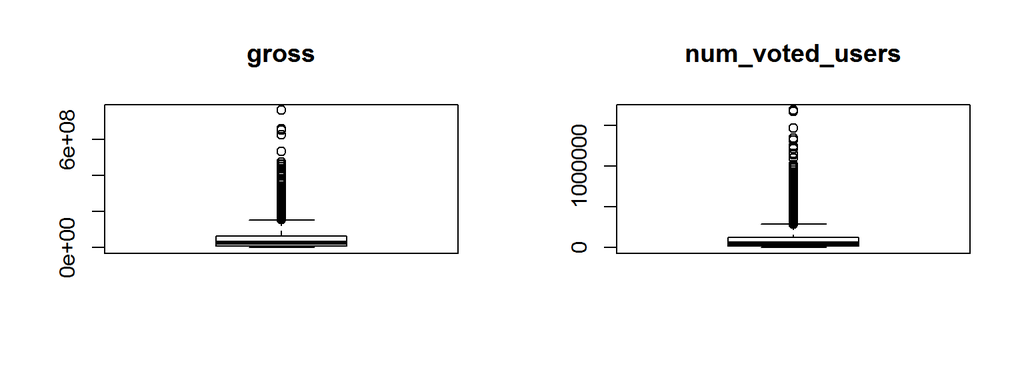

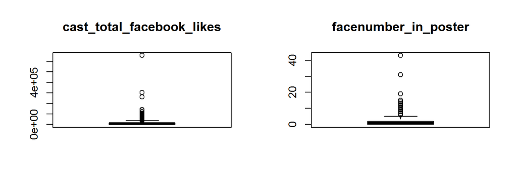

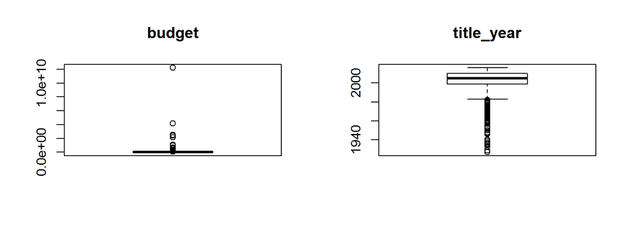

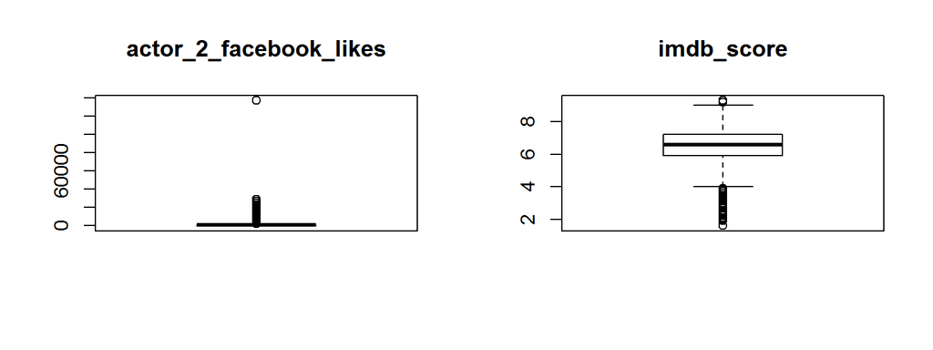

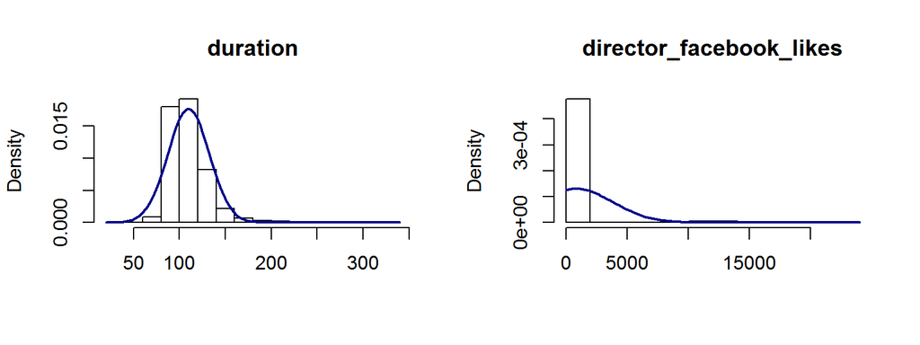

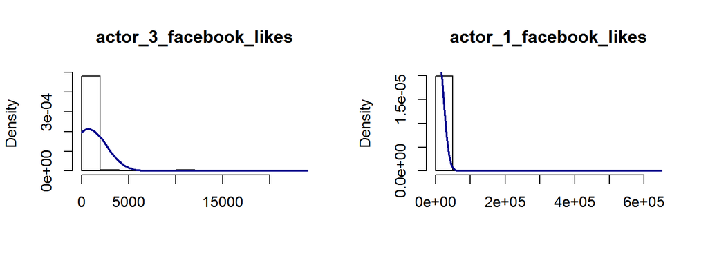

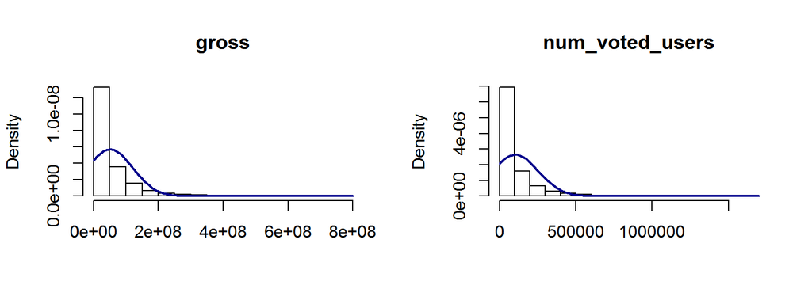

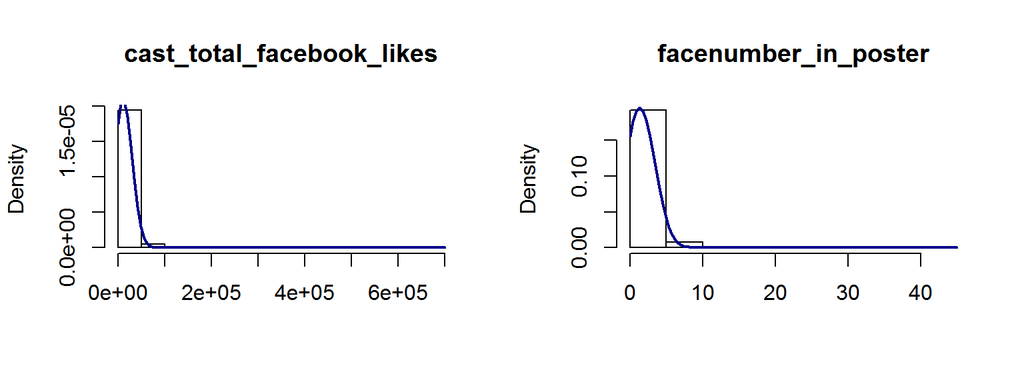

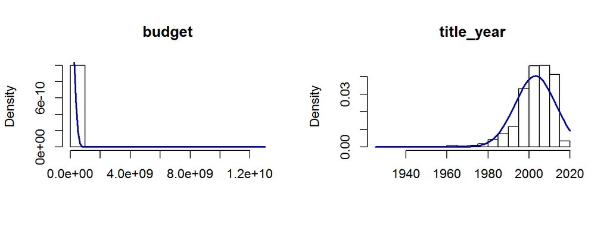

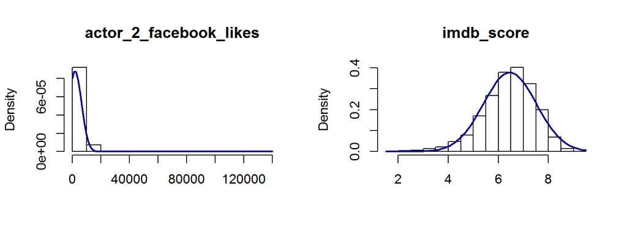

[6 more figures not shown]

After exploring the data, we noticed there is a scattering of NAs across the variables. Due to the relatively low number of total NAs, we choose to remove all rows with NAs, leaving 3,828 rows of data.

Next, the content_rating variable is converted to a factor so the rating categories can be used with the regression models.

## Data Preparation

One of the big issues faced in when using this dataset is the time frame. These movies were collected over the past 80+ years, and the following shows are distribution over time:

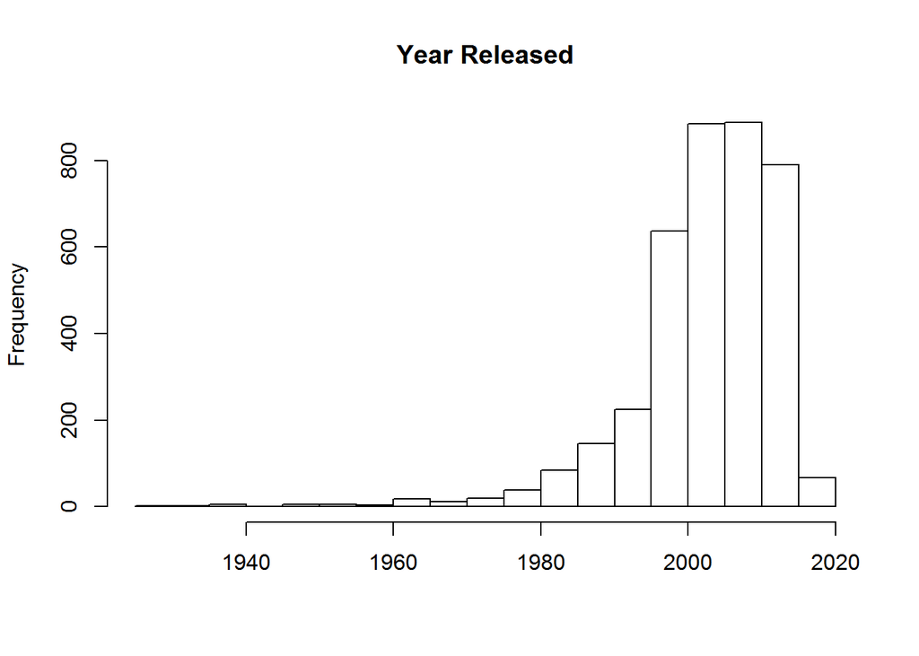

As you can see, the vast majority came from 1990s and above, but we can’t discredit the movies from previous year. In order to accurately portray elements from the past, we have instituted a rate of inflation calculation. Using the consumer price index (for our part here we are making a crucial assumption, that all dollars are calculated based on US currency, and we are ignoring even more complex foreign exchange rates of the time), we can calculate the gross value per year. As a basis of comparison, we are using the CPI index from 2016, as the last movie was made in 2016.

```r
movies <- merge(x = movies, y = cpi, by = "title_year")
movies$adj_gross <- with(movies, 240/cpi * gross)
movies$adj_budget <- with(movies, 240/cpi * budget)
movies$adj_margin <- with(movies, adj_gross-adj_budget)
```

```r
attach(movies)
```

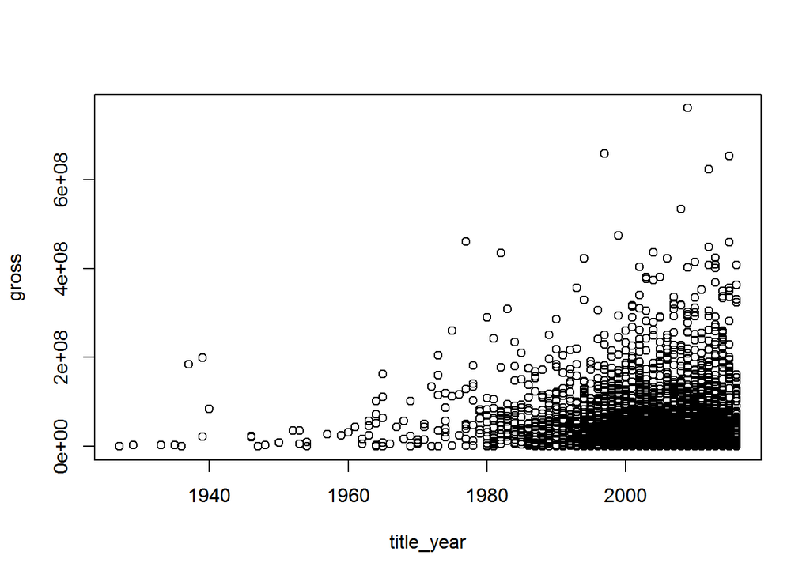

```r
plot(title_year,gross)
```

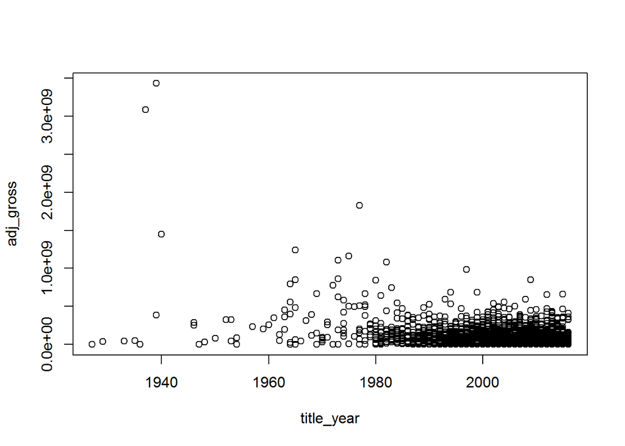

```r
plot(title_year,adj_gross)
```

From the above graphs, we can see that the adjustment for the gross did indeed create a more uniformed dataset (where as before we saw movies increasing over the years). As a point of interest, the movies that made over a billion dollars are shown below:

```r
highest_gross <- subset(movies, adj_gross > 1000000000,
                        select=c("movie_title", "gross","adj_gross") )
highest_gross
```

```
##                             movie_title     gross  adj_gross
## 6      Snow White and the Seven Dwarfs  184925485 3082091417
## 7                   Gone with the Wind  198655278 3430019188
## 9                            Pinocchio   84300000 1445142857
## 37                  The Sound of Music  163214286 1243537417
## 59                        The Exorcist  204565000 1105756757
## 69                                Jaws  260000000 1159851301
## 78  Star Wars: Episode IV - A New Hope  460935665 1825487782
## 133         E.T. the Extra-Terrestrial  434949459 1081739587
```

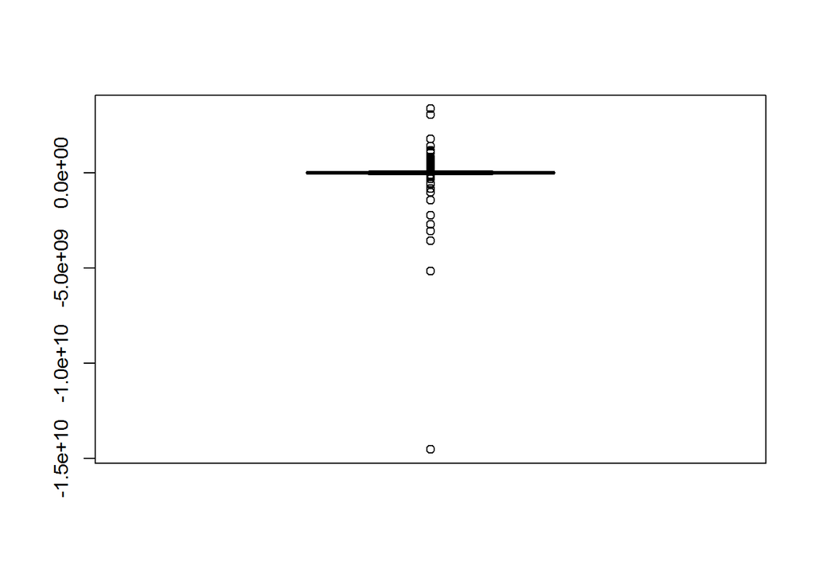

```r
boxplot(movies$adj_margin)
```

```r
subset(movies, adj_margin <= 0, select = c("movie_title", "adj_margin", "title_year"))
```

```
##                                                              movie_title
## 1                                                            Metropolis
## 5                                                          Modern Times
## 12                                               The Lady from Shanghai
## 13                                                           The Pirate
## 19                                                        Seven Samurai
## 25                                                   Lawrence of Arabia
## 29                                                    Nothing But a Man
## 33                                                   A Hard Day's Night
## 35                                                         Major Dundee
## 38                                         The Greatest Story Ever Told
## 46                                                  Mississippi Mermaid
## 49                                                         Darling Lili
## 50                                                    Tora! Tora! Tora!
## 60                                                         Mean Streets
```

[output cut: 3565 more lines]

Smooth Operators - All Done!